# Data Science Capstone

Exploratory Data Analysis

Rohan Lewis

2020.11.23

# I. Background

This is an exploratory data analysis of blogs, news, and tweets provided by the course.

This data will be eventually used for predicting the next word in a statement.

See the Appendix for code.

# II. Data

For each of Blogs, News, and Tweets, the following information is provided:

1. A summary of the data.
2. Word count distribution.
3. Character count distribution.
4. A list of the most common twenty words in the document.

## A. Blogs

### 1. Summary

```
There are 899,288 blogs in the file.
There are a total of 37,334,131 words and 206,824,505 characters in the file.
On average, each blog in the file has 41.5 words and 230 characters.
```

### 2. Word Distribution

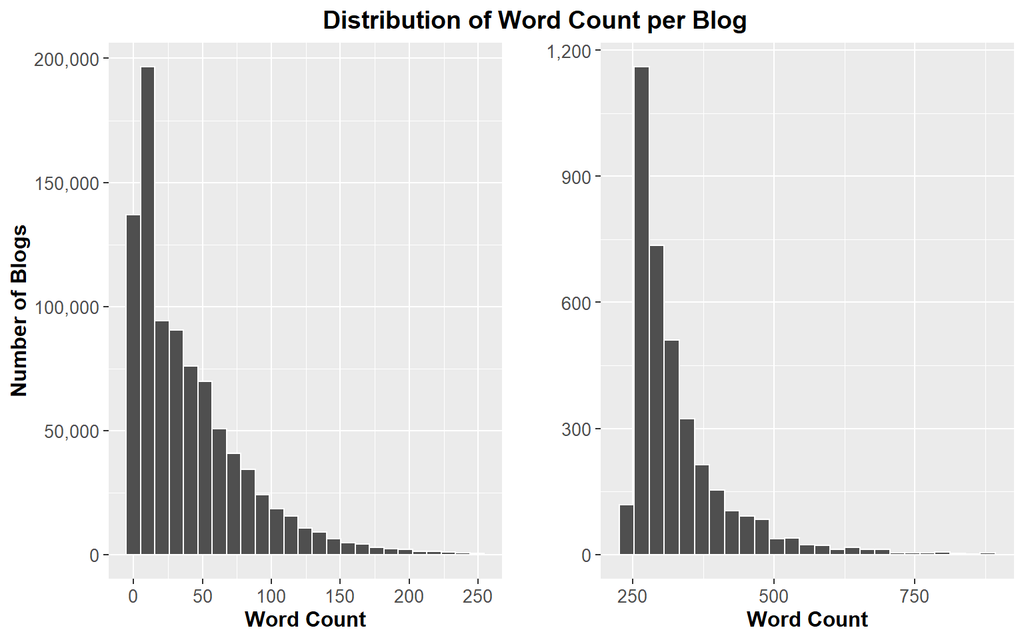

```
Remaining word counts in blogs are:
```

```
 [1] 1001 1003 1009 1014 1015 1024 1106 1127 1133 1157 1219 1295 1362 1380 1656
[16] 1716 2031 2079 2379 3283 6170 6630
```

### 3. Character Distribution

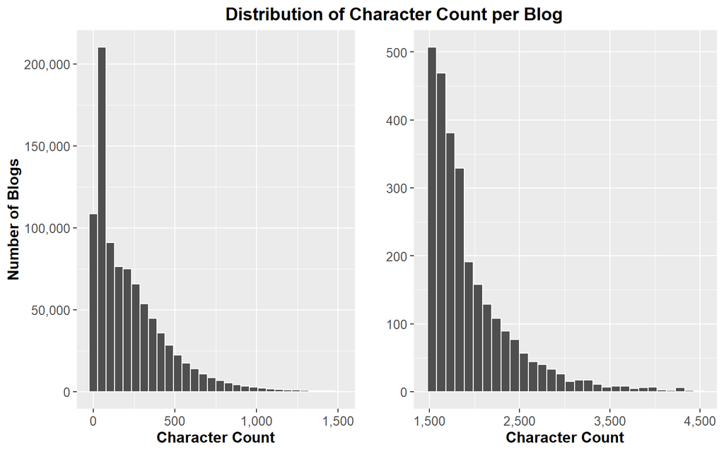

```
Remaining character counts in blogs are:
```

```
 [1]  4513  4527  4596  4606  4615  4702  4702  4714  4736  4772  4883  4919
[13]  4974  5054  5057  5385  5496  5557  5739  5883  6142  6179  6613  6886
[25]  7012  7375  8190  9189  9810 10785 12409 14201 19795 37191 40833
```

### 4. Most Common Words

```
29.9% of the total words are from the top 20.
```

```
   Word Frequency
1   the 1,860,156
2   and 1,094,401
3    to 1,069,440
4     a   900,362
5    of   876,799
6     i   775,032
7    in   598,532
8  that   460,782
9    is   432,712
10   it   403,902
11  for   363,838
12  you   298,702
13 with   286,733
14  was   278,347
15   on   276,511
16   my   270,855
17 this   259,008
18   as   223,949
19 have   218,930
20   be   209,061
```

## B. News

### 1. Summary

```
There are 1,010,242 news texts in the file.
There are a total of 34,372,530 words and 203,223,159 characters in the file.
On average, each news text in the file has 34 words and 201.2 characters.
```

### 2. Word Distribution

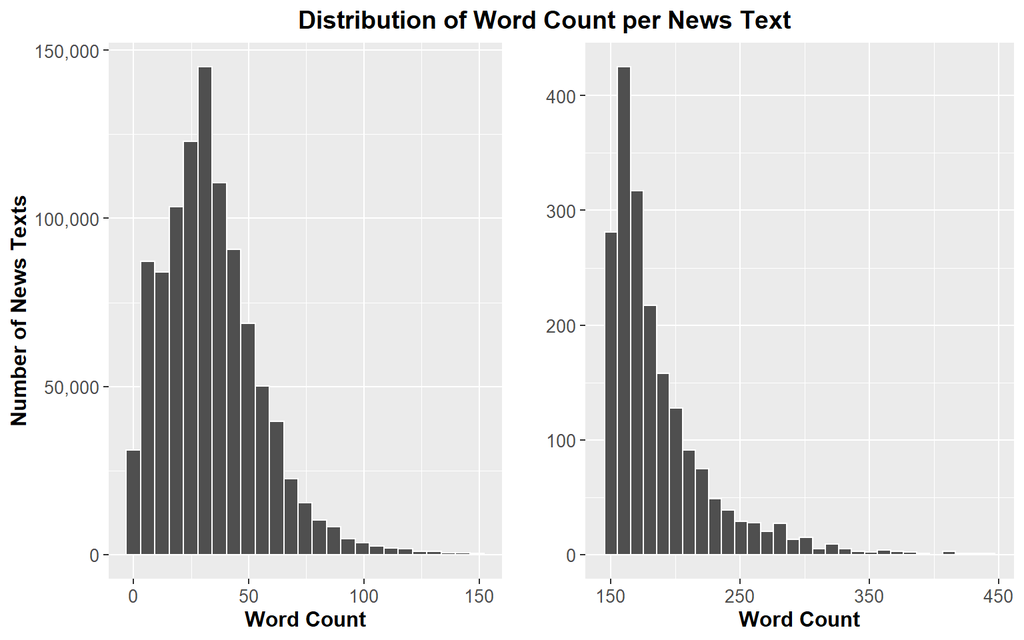

```
Remaining word counts in news texts are:
```

```
 [1]  451  458  460  463  480  485  507  517  521  563  691  708  870  898 1031
[16] 1370 1792
```

### 3. Character Distribution

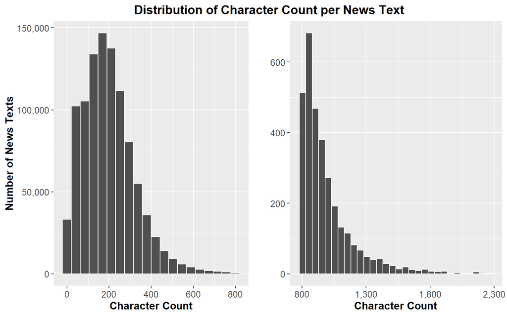

```
Remaining character counts in news texts are:
```

```
 [1]  2333  2363  2377  2386  2428  2442  2559  2581  2592  2625  2626  2644
[13]  2756  2785  2900  3008  3264  3555  3885  4198  5120  5236  5760  8949
[25] 11384
```

### 4. Word Frequencies

```
27.4% of the total words are from the top 20.
```

```
   Word Frequency
1   the 1,974,366
2    to   906,145
3   and   889,511
4     a   878,035
5    of   774,502
6    in   679,065
7   for   353,901
8  that   347,079
9    is   284,240
10   on   269,881
11 with   254,813
12 said   250,418
13   he   228,996
14  was   228,970
15   it   220,092
16   at   214,177
17   as   187,560
18    i   158,856
19  his   157,671
20   be   152,860
```

## C. Tweets

### 1. Summary

```
There are 2,360,148 tweets in the file.
There are a total of 30,373,543 words and 162,096,031 characters in the file.
On average, each tweet in the file has 12.9 words and 68.7 characters.
```

### 2. Word Distribution

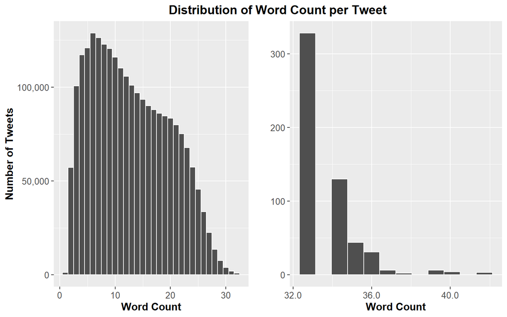

```
Remaining word counts in tweets are:
```

```
[1] 47
```

### 3. Character Distribution

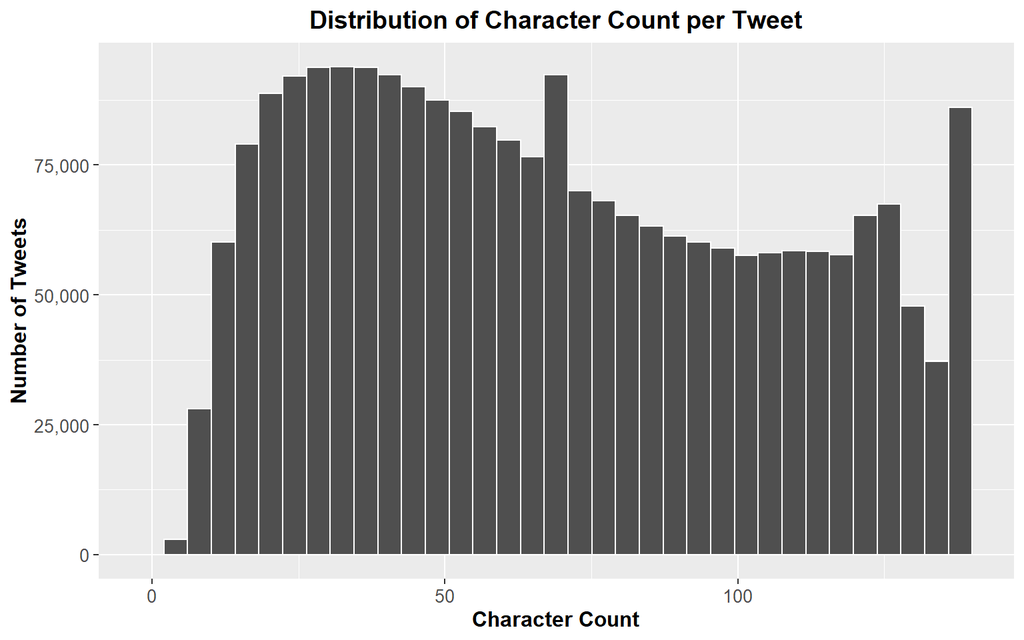

### 4. Word Frequencies

```
25.4% of the total words are from the top 20.
```

```
   Word Frequency
1   the   937,405
2    to   788,645
3     i   723,447
4     a   611,358
5   you   548,089
6   and   438,538
7   for   385,348
8    in   380,376
9    of   359,635
10   is   358,775
11   it   295,087
12   my   291,906
13   on   278,022
14 that   234,661
15   me   202,547
16   be   187,850
17   at   186,753
18 with   173,477
19 your   171,221
20 have   168,670
```

# III. Preliminary Analysis

The top 20 words for each data file are extremely similar, and account for a similar respective proportion for each data file.

To predict the next word for an input statement, the string will be run for each line in the three data files. If it matches, the next word will be saved. A frequency table will be made for all the words saved.

# Appendix

### Setup

```r
knitr::opts_chunk$set(comment = NA)
options("scipen" = 100)
```

### Packages

```r
library(dplyr)
library(ggplot2)
library(gridExtra)
library(ngram)
library(readr)
library(scales)
library(shiny)
library(tidyr)
library(tokenizers)
library(viridis)
```

### Read Files

```r
blogs <- read_lines(file = "en_US.blogs.txt")
news <- read_lines(file = "en_US.news.txt")
tweets <- read_lines(file = "en_US.twitter.txt")
```

### Helper Functions

```r
#This function will determine the total number of lines and the number of words and characters from each line.
words_chars <- function(many_lines){

  #Total Number of lines.
  total_lines <- length(many_lines)

  temp_df <- data.frame("Lines" = many_lines)

  #Number of words in each line.
  words <- apply(temp_df, 1, wordcount)
  #Number of characters in each line.
  chars <- apply(temp_df, 1, nchar)

  return(list(total_lines, words, chars))
}
```

```r
#This function will determine the total and average number of words and characters from all lines.
summary_stats <- function(info) {

  lines <- info[[1]]
  words <- info[[2]]
  chars <- info[[3]]

  num_words <- sum(words)
  avg_words <- round(num_words / lines, 1)

  num_chars <- sum(chars)
  avg_chars <- round(num_chars / lines, 1)

  return(list(lines, num_words, avg_words, num_chars, avg_chars))
}
```

```r
#This function will create a summary statement.
summary_statement <- function(label1, label2, summary_info) {

  lines <- summary_info[[1]]
  total_words <- summary_info[[2]]
  avg_words <- summary_info[[3]]
  total_chars <- summary_info[[4]]
  avg_chars <- summary_info[[5]]

  statement <- paste("There are",
                     prettyNum(lines, big.mark = ","),
                     label1,
                     "in the file.")

  total_statement <- paste("There are a total of",
                           prettyNum(total_words, big.mark = ","),
                           "words and",
                           prettyNum(total_chars, big.mark = ","),
                           "characters in the file.")

  avg_statement <- paste("On average, each",
                         label2,
                         "in the file has",
                         prettyNum(avg_words, big.mark = ","),
                         "words and",
                         prettyNum(avg_chars, big.mark = ","),
                         "characters.")

  cat(paste(statement,
            total_statement,
            avg_statement,
            sep = "\n"))
}
```

```r
#This function returns a table of the frequency of all words in a file, in descending order.
word_frequency <- function(many_lines, summary_info) {

  total_words <- summary_info[[2]]

  df <- data.frame(sort(table(tokenize_words(toString(many_lines))), decreasing = T)) %>%
    `colnames<-`(c("Word", "Frequency"))

  top_twenty <- sum(df[1:20, "Frequency"])
  word_percent <- paste(round(top_twenty * 100 / total_words, 1), "%", sep = "")

  cat(paste(word_percent,
            "of the total words are from the top 20."))

  df <- df[1:20,] %>%
    mutate(Frequency = prettyNum(Frequency, big.mark = ","))

  return(df)
}
```

```r
#Splits data into two parts.  The histogram is further split into two halves.

#Histogram
histogram_helper <- function(data_label, df, limit_1, limit_2, bins_1, bins_2, wc, title_shift){

  #Plural.
  label_plural = paste(data_label, "s", sep = "")
  #Main Title.
  title = paste("Distribution of",
                wc,
                "Count per",
                data_label)

  #The left half is where the vast majority of data is located.
  g1 <- ggplot(mapping = aes(x = df[df$Item < limit_1 + 1,]))
  g1 <- g1 + geom_histogram(bins = bins_1, color = "white", fill = "grey31")

  #Titles and Axes.
  g1 <- g1 + ggtitle("")
  g1 <- g1 + scale_x_continuous(name = paste(wc, "Count"), breaks = pretty_breaks(), labels = comma)
  g1 <- g1 + scale_y_continuous(name = paste("Number of", label_plural), labels = comma)

  #Modify labels and text.
  g1 <- g1 + theme(plot.title = element_text(size = 14, face = "bold"),
                   axis.text.x = element_text(size = 10),
                   axis.title.x = element_text(size = 12, face = "bold"),
                   axis.text.y = element_text(size = 10),
                   axis.title.y = element_text(size = 12, face = "bold"))

  #The right half contains most of the right skew.
  g2 <- ggplot(mapping = aes(x = df[df$Item > limit_1 & df$Item < limit_2 + 1,]))
  g2 <- g2 + geom_histogram(bins = bins_2, color = "white", fill = "grey31")

  #Titles and Axes.
  g2 <- g2 + ggtitle(title)
  g2 <- g2 + scale_x_continuous(name = paste(wc, "Count"),
                                breaks = c(limit_1, (2 * limit_1 + limit_2) / 3,
                                           (limit_1 + 2 * limit_2) / 3, limit_2),
                                labels = comma)
  g2 <- g2 + scale_y_continuous(name = "", labels = comma)

  #Modify labels and text.
  g2 <- g2 + theme(plot.title = element_text(hjust = title_shift, size = 14, face = "bold"),
                   axis.text.x = element_text(size = 10),
                   axis.title.x = element_text(size = 12, face = "bold"),
                   axis.text.y = element_text(size = 10),
                   axis.title.y = element_text(size = 12, face = "bold"))

  #Combine two halves.
  grid.arrange(g1, g2, layout_matrix = matrix(c(1, 2), ncol = 2))

  #The remaining extreme right skew is printed out.
  cat(paste("Remaining",
          tolower(wc),
          "counts in",
          tolower(label_plural),
          "are: "))

  sort(df[df$Item > limit_2,])
}
```

# II. Data

## A. Blogs

### 1. Summary

```r
info_b <- words_chars(blogs)

summary_info_b <- summary_stats(info_b)

summary_statement("blogs", "blog", summary_info_b)
```

### 2. Word Distribution

```r
df <- data.frame("Item" = info_b[[2]])

histogram_helper("Blog", df, 250, 1000, 25, 25, "Word", 25)
```

### 3. Character Distribution

```r
df <- data.frame("Item" = info_b[[3]])

histogram_helper("Blog", df, 1500, 4500, 30, 30, "Character", 5.5)
```

### 4. Most Common Words

```r
word_frequency(blogs, summary_info_b)
```

## B. News

### 1. Summary

```r
info_n <- words_chars(news)

summary_info_n <- summary_stats(info_n)

summary_statement("news texts", "news text", summary_info_n)
```

### 2. Word Distribution

```r
df <- data.frame("Item" = info_n[[2]])

histogram_helper("News Text", df, 150, 450, 25, 30, "Word", 4.5)
```

### 3. Character Distribution

```r
df <- data.frame("Item" = info_n[[3]])

histogram_helper("News Text", df, 800, 2300, 20, 30, "Character", 2.7)
```

### 4. Word Frequencies

```r
word_frequency(news, summary_info_n)
```

## C. Tweets

### 1. Summary

```r
info_t <- words_chars(tweets)

summary_info_t <- summary_stats(info_t)

summary_statement("tweets", "tweet", summary_info_t)
```

### 2. Word Distribution

```r
df <- data.frame("Item" = info_t[[2]])

histogram_helper("Tweet", df, 32, 44, 32, 12, "Word", 22)
```

### 3. Character Distribution

```r
df <- data.frame("Item" = info_t[[3]])

#Main Title.
title = paste("Distribution of Character Count per Tweet")

g <- ggplot(mapping = aes(x = df$Item))
g <- g + geom_histogram(bins = 35, color = "white", fill = "grey31")

#Titles and Axes.
g <- g + ggtitle(title)
g <- g + scale_x_continuous(name = paste("Character Count"), labels = comma)
g <- g + scale_y_continuous(name = paste("Number of Tweets"), labels = comma)

#Modify labels and text.
g <- g + theme(plot.title = element_text(hjust = 0.5, size = 14, face = "bold"),
               axis.text.x = element_text(size = 10),
               axis.title.x = element_text(size = 12, face = "bold"),
               axis.text.y = element_text(size = 10),
               axis.title.y = element_text(size = 12, face = "bold"))
g
```

### 4. Word Frequencies

```r
word_frequency(tweets, summary_info_t)
```